If you are having trouble accessing Jupyter Notebooks, there are a few different things to try. First though, Jupyter functions on current versions of Firefox, Safari and Chrome, and Chrome seems to work the best. If you are using one of those browsers, then work through some of the trouble shooting tips below to try and resolve the problem:

**Shut Down Your Notebook:**

- To shutdown notebooks, click the "Running" tab on your Jupyter home page and click "Shutdown" on the right (see image below).
- Restart notebook
- Usually these errors are temporary and will resolve themselves when our automated server monitoring notices an issue with the server and restarts the server.

**Restarting Your Computer:**

- If simply shutting down the notebook did not resolve the issue, please follow these steps sequentially:
1. Clear your computers cookies/cache.
2. Disconnect from the internet.
3. Restart your computer
4. Connect to the internet again
5. Try logging back into Coursera and opening up your Jupyter Notebook.

**Firewall Issue:**

- A correctly-formatted Jupyter notebook URL looks like this: https://mooc-az-YY.oit.duke.edu:XXXXX/notebooks/notebook_name.ipynb
- YY is a two-digit server number (ranging from 00 - 59) and XXXXX is the 5-digit port number (ranging from 40000 - 40139; each learner on a server is on a different port, so each learner has a unique URL).
- If you set up your own firewall or have firewall-type settings enabled on your PC, you should open your specific port (or the port range 40000 - 40139) for your server URL. The server URL is https://mooc-az-YY.oit.duke.edu, substituting the appropriate two digits (00 - 59) for YY.
- If you use a corporate network with a firewall (meaning that you do not control the firewall), you could try using a VPN service to tunnel past the corporate firewall if it is acceptable to install such software on your computer, or you could try asking your company's IT support person for recommendations on how to access the server and port you are trying to reach. You could also just use a different computer or location that does not require you to login through your corporate network firewall.

**Help Others!**

- Please shutdown any running Jupyter notebooks after you finish working in the notebook to reduce the processing load on the server and improve performance for other learners. Think of this as shutting off the lights when you are finished in a room in your house.
- To shutdown notebooks, please click the "Running" tab on your Jupyter home page and click "Shutdown" on the right, as shown in the following screenshot. Thank you!

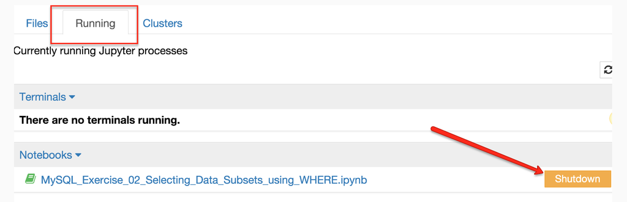